# EXAMINING RED WINE QUALITY by RAGHAV BATRA

# Bivariate Plots Section

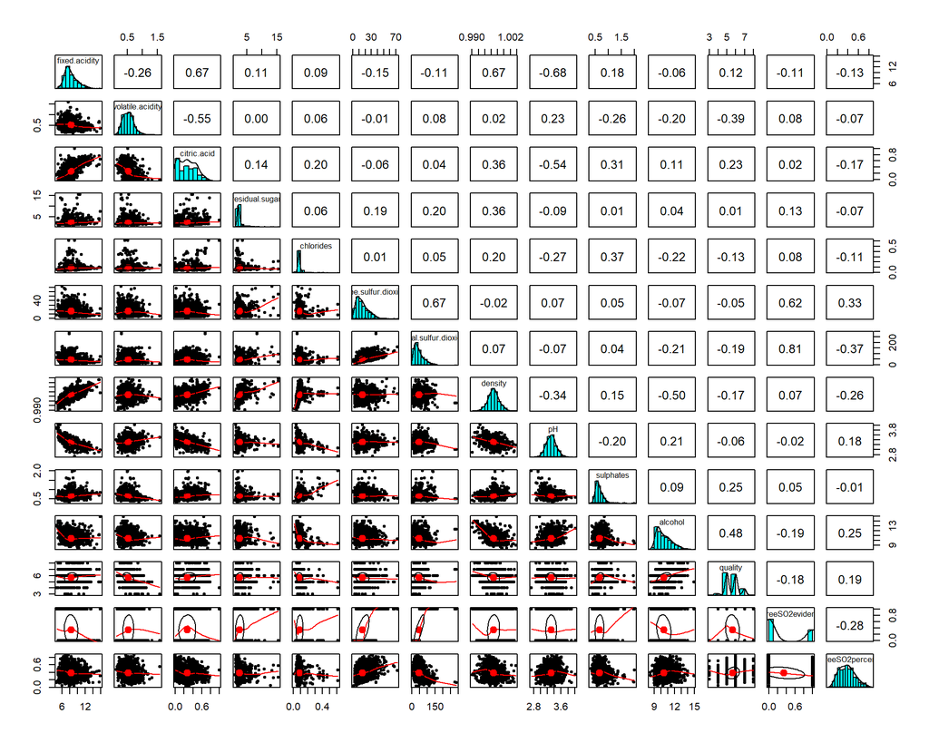

Looking at the plot correlation values, let us see the relation between quality and alcohol/volatile.acidity/citric.acid

#### Boxplot of alcohol vs quality

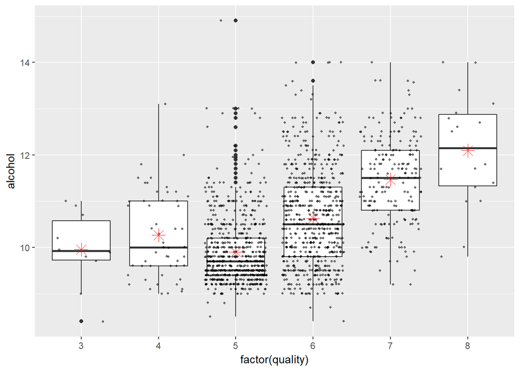

```
##
##  Pearson's product-moment correlation
##
## data:  alcohol and quality
## t = 21.639, df = 1597, p-value < 2.2e-16
## alternative hypothesis: true correlation is not equal to 0
## 95 percent confidence interval:
##  0.4373540 0.5132081
## sample estimates:
##       cor
## 0.4761663
```

#### Boxplot of volatile acidity vs quality

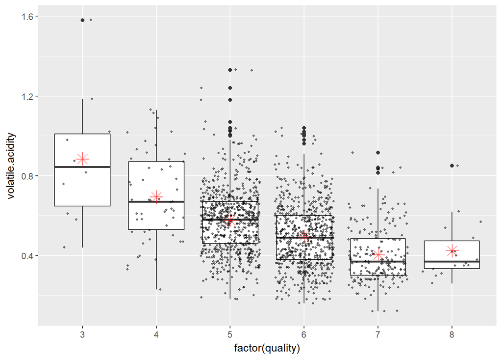

```
##
##  Pearson's product-moment correlation
##
## data:  volatile.acidity and quality
## t = -16.954, df = 1597, p-value < 2.2e-16
## alternative hypothesis: true correlation is not equal to 0
## 95 percent confidence interval:
##  -0.4313210 -0.3482032
## sample estimates:
##        cor
## -0.3905578
```

This graph agrees on the fact that ‘too high of levels can lead to an unpleasant, vinegar taste’.

Both scatterplots above do not seem to benefit from any transformations of axes, and as such their relationship should not be altered.

#### Boxplot of citric acid vs quality

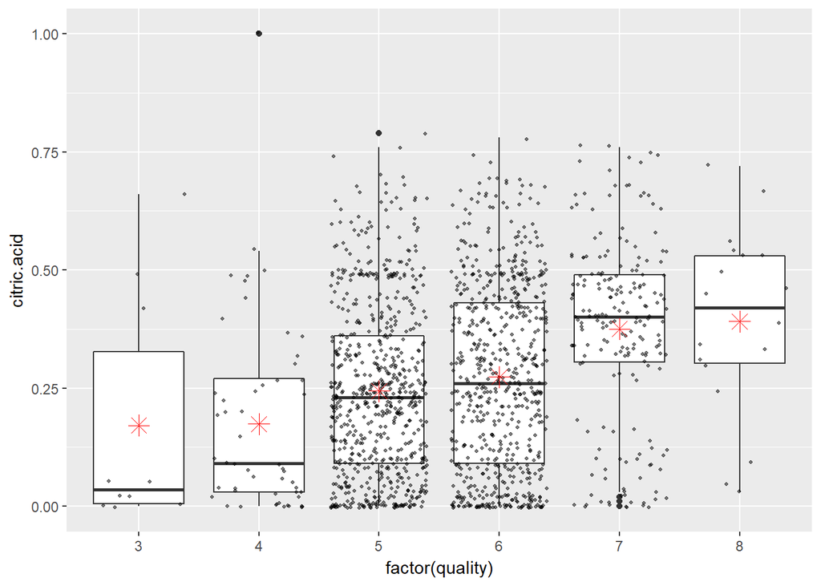

```
##
##  Pearson's product-moment correlation
##
## data:  citric.acid and quality
## t = 9.2875, df = 1597, p-value < 2.2e-16
## alternative hypothesis: true correlation is not equal to 0
## 95 percent confidence interval:
##  0.1793415 0.2723711
## sample estimates:
##       cor
## 0.2263725
```

#### Boxplot of residual sugar vs quality

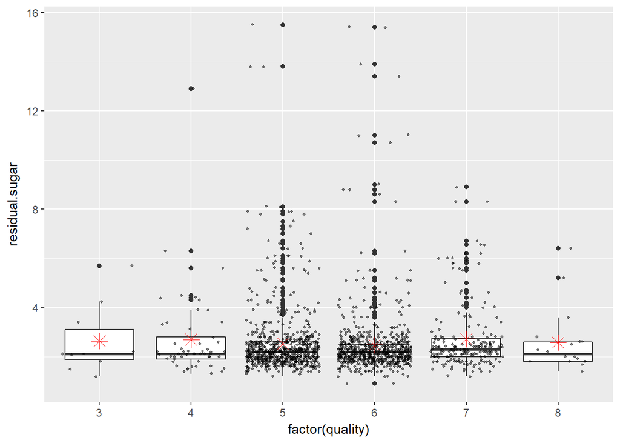

```
##
##  Pearson's product-moment correlation
##
## data:  residual.sugar and quality
## t = 0.5488, df = 1597, p-value = 0.5832
## alternative hypothesis: true correlation is not equal to 0
## 95 percent confidence interval:
##  -0.03531327  0.06271056
## sample estimates:
##        cor
## 0.01373164
```

While there is no clear cut trend seen, it is apparent from the above graph that at levels < 4, there is not much difference between quality, and at levels > 10, there are mostly lower quality wines. Thus, it might seem beneficial to concentrate only on the low to middle set of values (2 - 6).

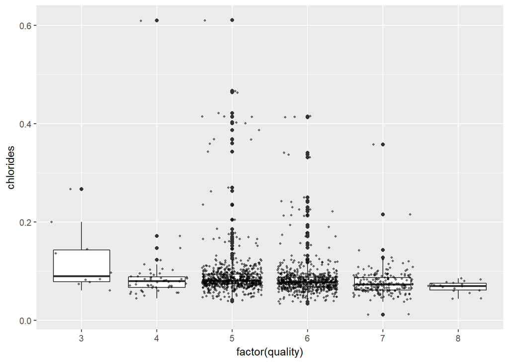

```
##
##  Pearson's product-moment correlation
##
## data:  chlorides and quality
## t = -5.1948, df = 1597, p-value = 2.313e-07
## alternative hypothesis: true correlation is not equal to 0
## 95 percent confidence interval:
##  -0.17681041 -0.08039344
## sample estimates:
##        cor
## -0.1289066
```

Like residual sugar, there does not seem to be any clear trend, but better quality wines generally have low levels (<= 0.2) of chlorides.

#### Boxplot of sulphates vs quality

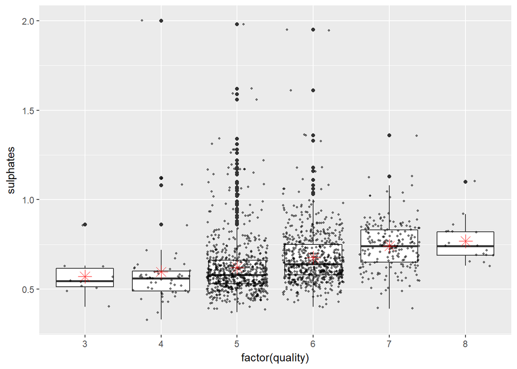

```
##
##  Pearson's product-moment correlation
##
## data:  sulphates and quality
## t = 10.38, df = 1597, p-value < 2.2e-16
## alternative hypothesis: true correlation is not equal to 0
## 95 percent confidence interval:
##  0.2049011 0.2967610
## sample estimates:
##       cor
## 0.2513971
```

While there is a very gradual upward trend, there are also virtually no high quality alcohols after a sulphate level of 1.

#### Boxplot of freeSO2percent vs quality

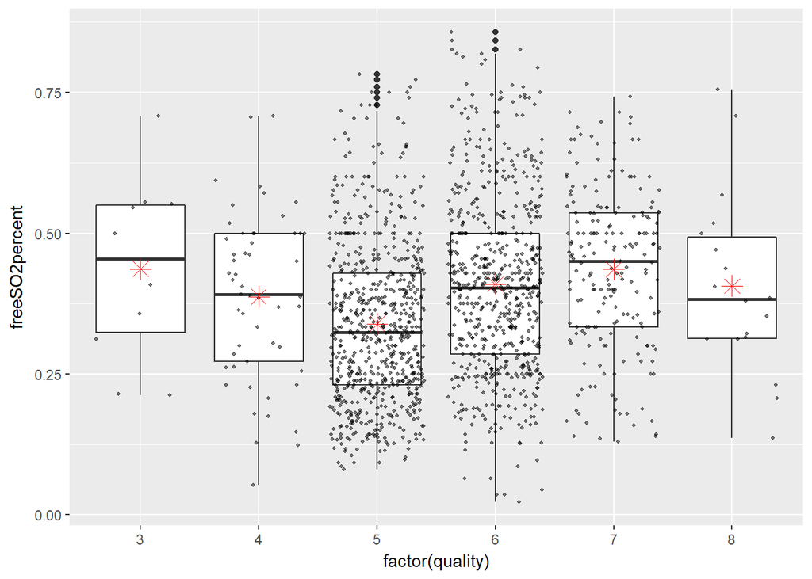

```
##
##  Pearson's product-moment correlation
##
## data:  freeSO2percent and quality
## t = 7.9077, df = 1597, p-value = 4.854e-15
## alternative hypothesis: true correlation is not equal to 0
## 95 percent confidence interval:
##  0.1464861 0.2408427
## sample estimates:
##       cor
## 0.1941134
```

#### Scatterplot of fixed acidity vs citric acid

[figure not shown]

```r
with(redWine, cor.test(fixed.acidity, citric.acid))
```

```
##
##  Pearson's product-moment correlation
##
## data:  fixed.acidity and citric.acid
## t = 36.234, df = 1597, p-value < 2.2e-16
## alternative hypothesis: true correlation is not equal to 0
## 95 percent confidence interval:
##  0.6438839 0.6977493
## sample estimates:
##       cor
## 0.6717034
```

#### Scatterplot of volatile acidity vs citric acid

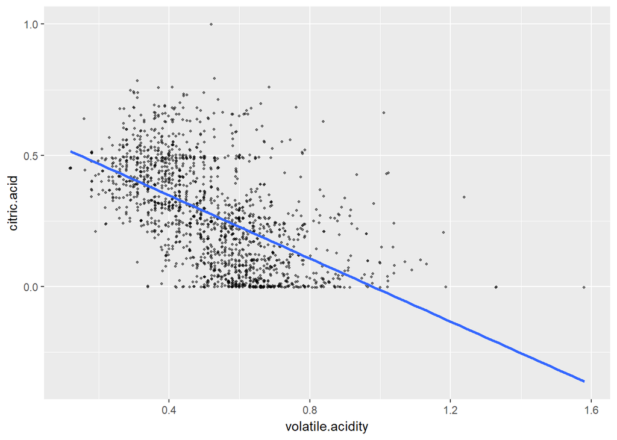

```r
with(redWine, cor.test(volatile.acidity, citric.acid))
```

```
##
##  Pearson's product-moment correlation
##
## data:  volatile.acidity and citric.acid
## t = -26.489, df = 1597, p-value < 2.2e-16
## alternative hypothesis: true correlation is not equal to 0
## 95 percent confidence interval:
##  -0.5856550 -0.5174902
## sample estimates:
##        cor
## -0.5524957
```

The scatterplots above are self explanatory in the relationships among the 3 acids in red wine.

# Bivariate Analysis

### Talk about some of the relationships you observed in this part of the investigation. How did the feature(s) of interest vary with other features in the dataset?

From the obvious scatterplots and correlation tests, it seems that alcohol quality is heavily correlated with:

1. higher alcohol percent (positive).
2. lower volatile acidity (negative).

### Did you observe any interesting relationships between the other features (not the main feature(s) of interest)?

1. Fixed acidity (tartaric acid) and citric acid have a highly positive relation.
2. Volatile acidity (acetic acid) and citric acid have a mediocrely negative relation.

As quality and citric acid levels are positively correlated, this implies better quality red wines have higher tartaric acid and lower acetic acid content.

# Multivariate Plots Section

#### Alcohol & volatile aciity by quality

It can be seen that better quality wines tend to move from the upper left to the lower right of the graph, thus confirming more alcohol and less volatile.acid lead to better quality wines

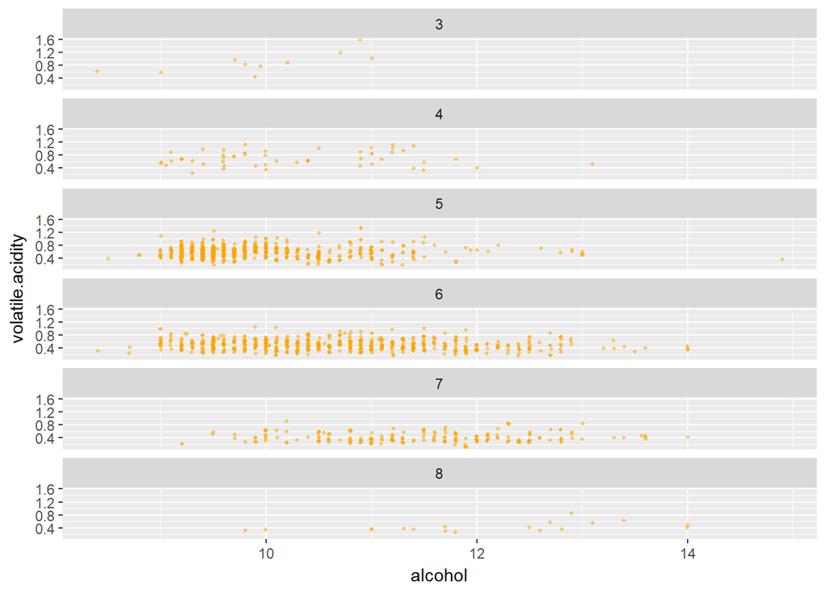

#### Alcohol percent by quality (part 1)

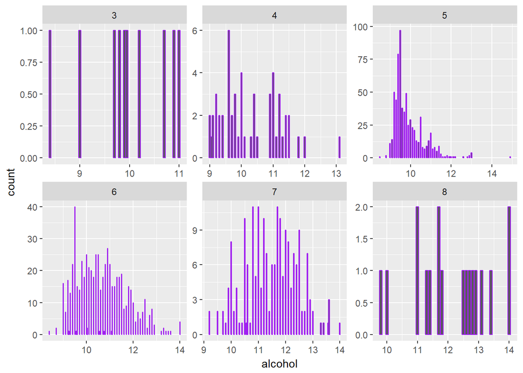

As discussed in the last section, alcohol and quality are positively correlated. This can be seen in the fact that wines with quality >= 7 have more alcohol content towards 12, 13 and even 14, whereas lower quality wines have more alcohol content near 9 and 10.

#### Alcohol by quality (part 2)

The plots below confirm our analysis: wines with qualities of 3, 4 and 5 have negligibe number of points with alcohol percent between 13 and 14, while higher quality wines clearly have more points.

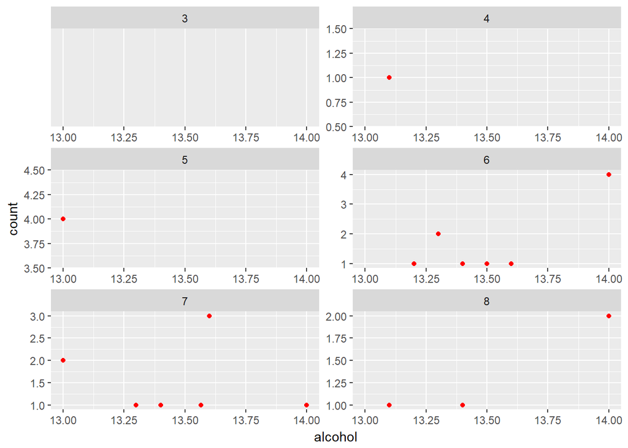

#### Chlorides by quality

Confirming our analysis above, we see that as the quality increases, so does the number of points below the 0.2 threshhold (discussed in bivariate summary)

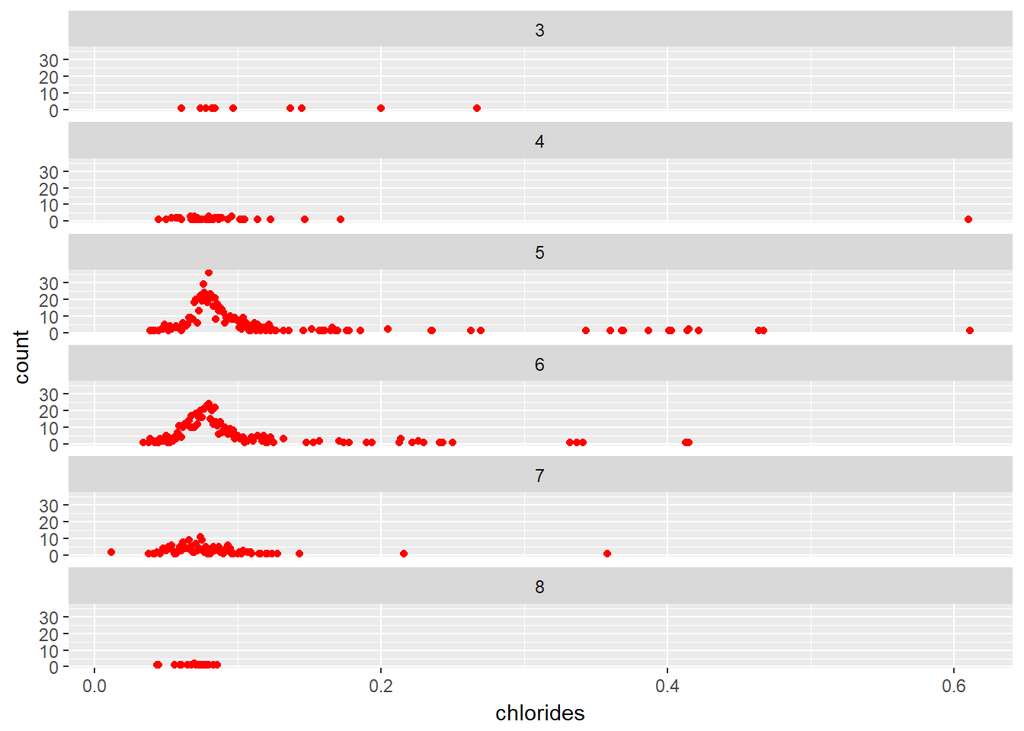

#### Sulphates by quality

Confirming our analysis once again, we see that as the quality increases, so does the number of points below the 1 threshhold (discussed in bivariate summary)

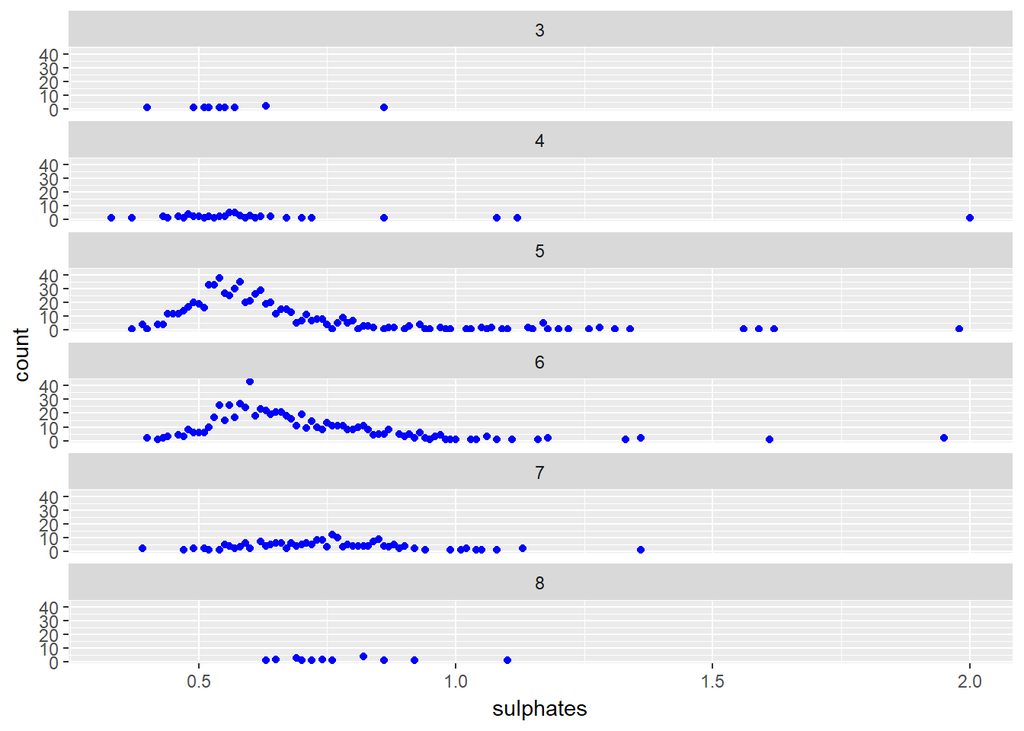

#### pH by quality

We haven’t looked at pH so far, because it didn’t have much correlation. Let’s confirm this!

From the graph below, there seems to be no clear effect of pH on quality. However, the above statement might be true only because the pH scale is on the acidic side.

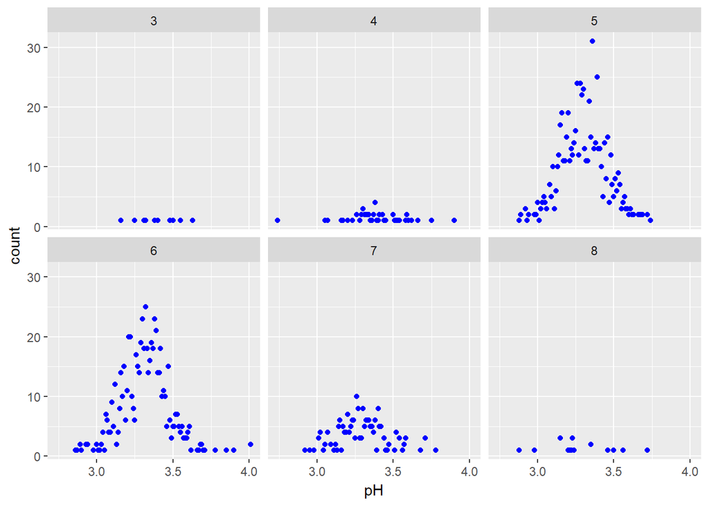

#### Density & freeSO2percent by quality

As with pH, let’s confirm density and freeSO2percent do not in fact contribute majorly to quality.

If we see the confidence ellipses below, they seem to cover nearly the same region regardless of quality.

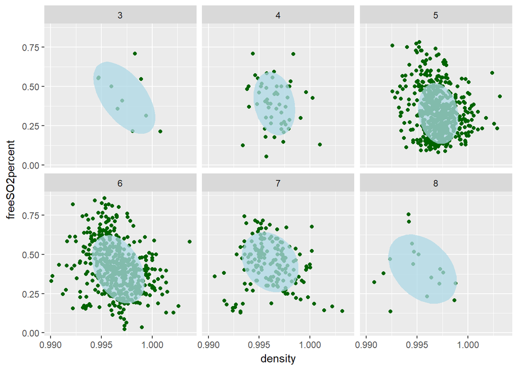

#### Modelling the dataset

Let’s model the data to predict quality!

```r
redWine_cleaned = subset(redWine, (redWine$chlorides <= 0.11 & redWine$chlorides >= 0.03)
                         & redWine$sulphates <= 1.0
                         & (redWine$residual.sugar >= 2 & redWine$residual.sugar <= 6)
                         & redWine$citric.acid <= 0.7)

redWine_cleaned$id = redWine_cleaned$X

m1 <- lm(quality ~ alcohol, data = redWine_cleaned)

m2 <- update(m1, ~ . + volatile.acidity)
m3 <- update(m2, ~ . + sulphates)
m4 <- update(m3, ~ . + chlorides)
m5 <- update(m4, ~ . + residual.sugar)
m6 <- update(m5, ~ . + citric.acid)

mtable(m1, m2, m3, m4, m5, m6)
```

```
##
## Calls:
## m1: lm(formula = quality ~ alcohol, data = redWine_cleaned)
## m2: lm(formula = quality ~ alcohol + volatile.acidity, data = redWine_cleaned)
## m3: lm(formula = quality ~ alcohol + volatile.acidity + sulphates,
##     data = redWine_cleaned)
## m4: lm(formula = quality ~ alcohol + volatile.acidity + sulphates +
##     chlorides, data = redWine_cleaned)
## m5: lm(formula = quality ~ alcohol + volatile.acidity + sulphates +
##     chlorides + residual.sugar, data = redWine_cleaned)
## m6: lm(formula = quality ~ alcohol + volatile.acidity + sulphates +
##     chlorides + residual.sugar + citric.acid, data = redWine_cleaned)
##
## ======================================================================================
##                        m1         m2         m3         m4         m5         m6
## --------------------------------------------------------------------------------------
##   (Intercept)        1.823***   2.962***   2.089***   2.178***   2.187***   2.226***
##                     (0.227)    (0.238)    (0.248)    (0.315)    (0.315)    (0.318)
##   alcohol            0.365***   0.326***   0.282***   0.279***   0.281***   0.281***
##                     (0.022)    (0.021)    (0.020)    (0.021)    (0.022)    (0.022)
##   volatile.acidity             -1.369***  -0.936***  -0.935***  -0.930***  -1.005***
##                                (0.124)    (0.129)    (0.129)    (0.129)    (0.153)
##   sulphates                                1.724***   1.723***   1.729***   1.747***
##                                           (0.192)    (0.192)    (0.192)    (0.193)
##   chlorides                                          -0.742     -0.544     -0.332
##                                                      (1.621)    (1.649)    (1.666)
##   residual.sugar                                                -0.018     -0.016
##                                                                 (0.028)    (0.028)
##   citric.acid                                                              -0.126
##                                                                            (0.138)
## --------------------------------------------------------------------------------------
##   R-squared              0.2       0.3        0.4        0.4        0.4        0.4
##   adj. R-squared         0.2       0.3        0.4        0.4        0.4        0.4
##   sigma                  0.7       0.7        0.6        0.6        0.6        0.6
##   F                    286.1     221.9      187.2      140.3      112.3       93.7
##   p                      0.0       0.0        0.0        0.0        0.0        0.0
##   Log-likelihood     -1031.8    -974.2     -935.2     -935.1     -934.9     -934.5
##   Deviance             478.3     424.6      391.7      391.6      391.5      391.1
##   AIC                 2069.6    1956.4     1880.4     1882.2     1883.8     1884.9
##   BIC                 2084.2    1975.9     1904.8     1911.5     1917.9     1923.9
##   N                    967       967        967        967        967        967
## ======================================================================================
```

# Multivariate Analysis

### Talk about some of the relationships you observed in this part of the investigation. Were there features that strengthened each other in terms of looking at your feature(s) of interest?

Advancing on my analyses in the Bivariate section, I confirmed the trends I saw in the Univariate & Bivariate sections.

There were no other new findings; only confirmations of old findings by facetting each of the variables on quality.

Facetting by quality makes the finding easier to see visually!

### Were there any interesting or surprising interactions between features?

I found that squishing and arranging the data columnwise in one column is even better than presenting the data in larger windows.

### OPTIONAL: Did you create any models with your dataset? Discuss the strengths and limitations of your model.

Yes, I did.

I found the R^2 to be very low: 0.4. This is probably because I didn’t use all the factors, just the main ones.

Even so, all wines in the dataset were mediocrely acidic, and I am pretty sure there are other factors not mentioned in the dataset that affect wine quality.

Finally, there wasn’t much variety in the wine qualities of the dataset (only from 3 to 8), thus presenting only 50% of the values.

However, I did subset the data to better fit it, so I think it should be alright, if not great to predict wine quality.

# Final Plots and Summary

### Plot One

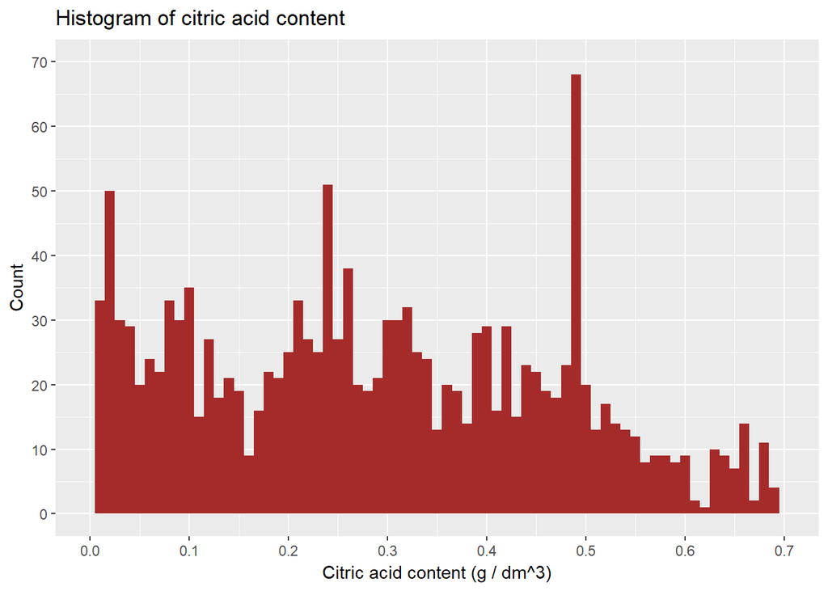

### Description One

This plot displays the histogram of wines by citric acid content.

Though it might not have been very useful in determining the final quality, this graph has 2 interesting features:

1. the spike at 0.0
2. the spike at 0.5

While these may have been numerical errors, some research on my side told me that red wines generally have very little citric content.

Regarding the spike at 0.5, on further examination, all wines with such levels seemed to fit in with the data.

Thus, it turns out that both spikes were in fact alright! This is why I liked this graph: it gave me opportunities to both do some research and perform further analyses on what I thought was wrong. This is the whole point of this course!

Thus, while displaying counts, this graph also presents some interesting findings.

### Plot Two

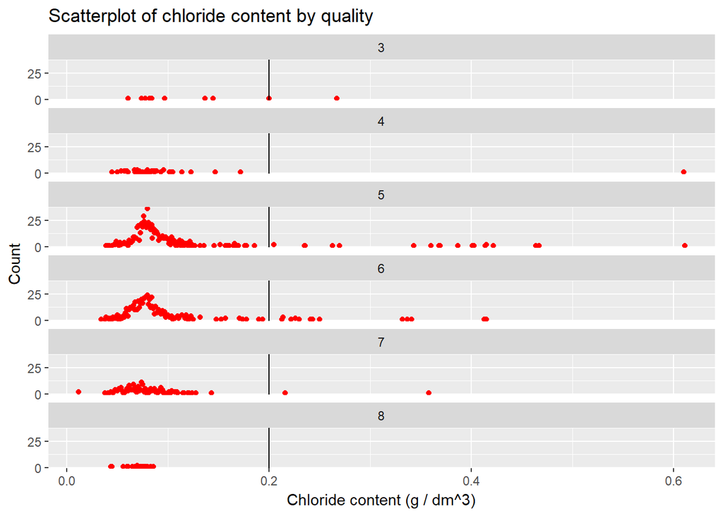

### Description Two

This is a scatterplot of chloride content by quality.

While most people would not choose this graph for their final visualization because it’s too squishy, I actually like it because it achieves what I want from it very well.

By displaying everything in one column, it is easy to see how the data points for chloride content decrease to below 0.2 as the wine quality increases from 3 to 8.

I also like the vertical line at 0.2: it seems like a safety marker for the dataset: you’re safe if you’re below it!

Infact, better quality have chloride content below 0.2.

### Plot Three

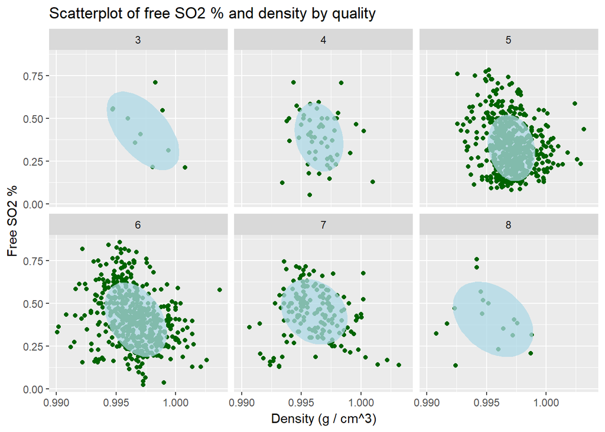

### Description Three

This is a scatterplot of free SO2 % and density by quality.

There are 2 reasons I like this plot:

1. the fact I can now compare 3 variables with such little code is awesome to know!
2. To enter the confidence ellipse, I once again had to research. However, better than the research was the fact that theoretical concepts like confidence intervals could be applied to actual data so easily. It also makes what I want to say about the confidence intervals being similar easier!

# Reflection

Phew! This was an interesting assignment. I found the layout of analyses to perform in the skeleton Markdown file very easy to follow. The fact I could perform so many analyses so easily was much appreciated!

The main struggle with me were the new commands. I had to stop my train of thought, Google the queries and then try again if it didn’t work. However, tough as that may have been, I was happy I did so because there is no other way to this kind of learning!

Generally though, everything else went well. I would have liked more categorical variables. This is not to say I couldn’t create some (I did create one!); it’s just that they wouldn’t have given me any more information.

I genuinely learnt a lot about red wines and various chemicals.

Future insight could include comparing these results to results for some other type of alcohol such as gin or whiskey.

It would also be interesting to do a time series analysis of the chemicals and quality of the wine as it aged.